# SOIL BEHAVIOUR TYPE CHARTS

Erdi Myftaraga

[MAIN PAGE](https://erdirstats.github.io/)

# 1 INTRODUCTION

It can be useful sometimes to create an idea on how the `CPTU` measurement points of a particular site or soil unit are distributed among different `SBT` (Soil Behavior Type) zones. I wrote a small function to categorize `CPTU` data points according to the zone they plot in a few `SBT` charts, as listed:

- `Robertson 2009` `SBT` chart[^1];
- `Robertson 2016` `SBT` chart[^2];
- `Schneider et al. 2008` `SBT` chart[^3] (modified by Robertson 2016).

# 2 PLOTS

Some example plots with sample data are shown below.

## 2.1 Robertson 2009

### ALL ZONES

Same plot for all `SBT` zones:

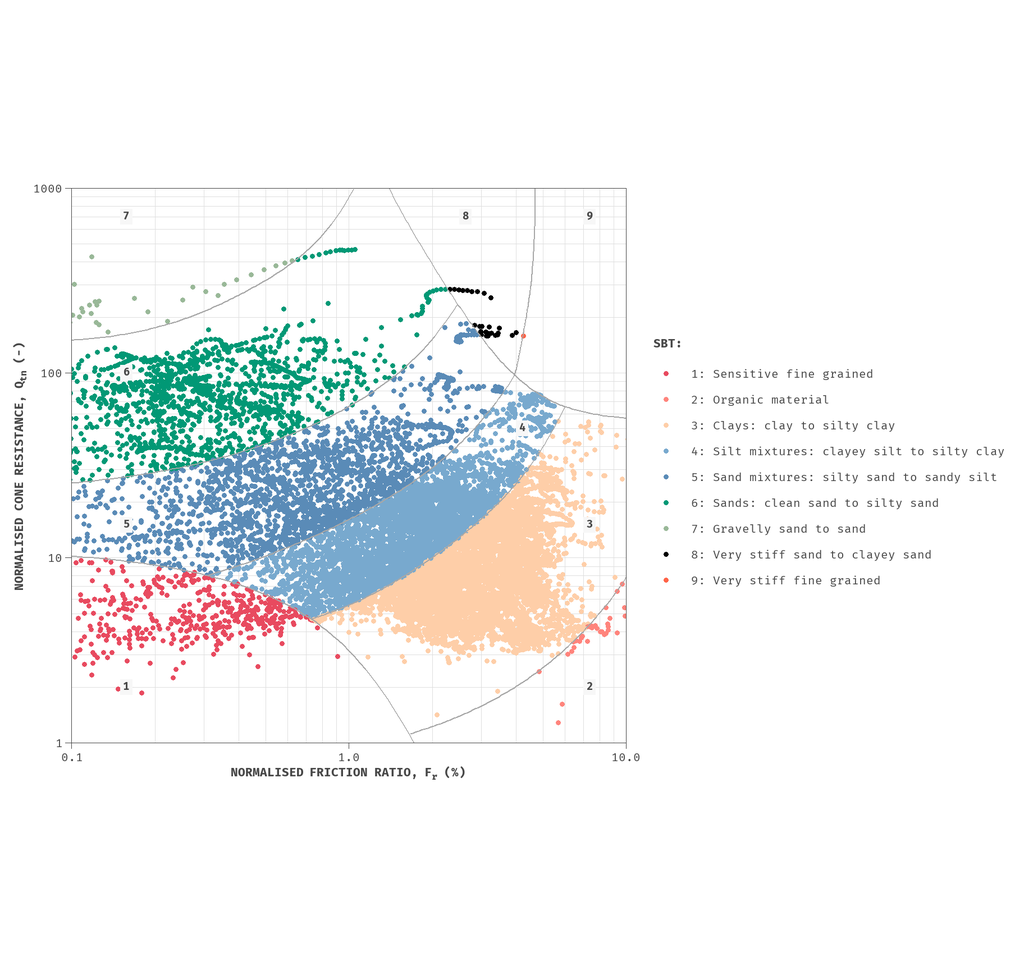

### SEPARATED

Separated plots for each `SBT` zone:

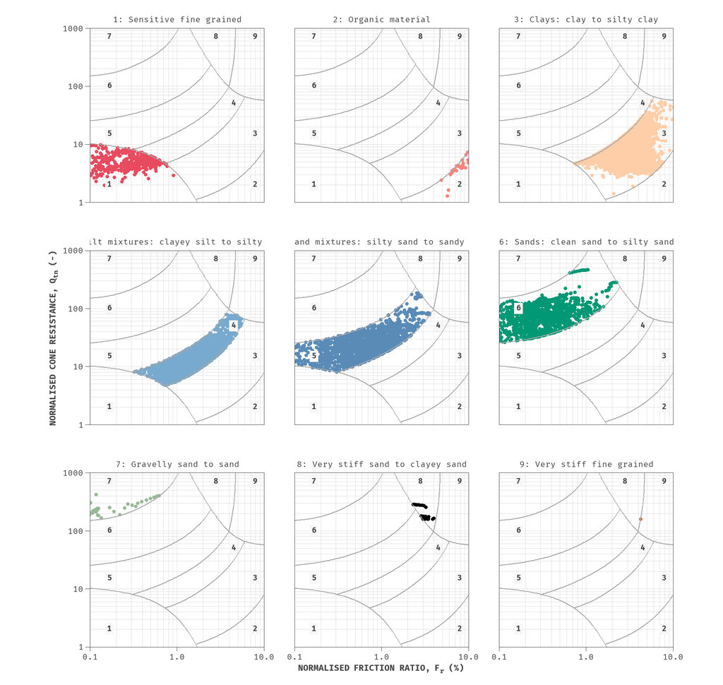

## 2.2 Robertson 2016

### ALL ZONES

Same plot for all `SBT` zones:

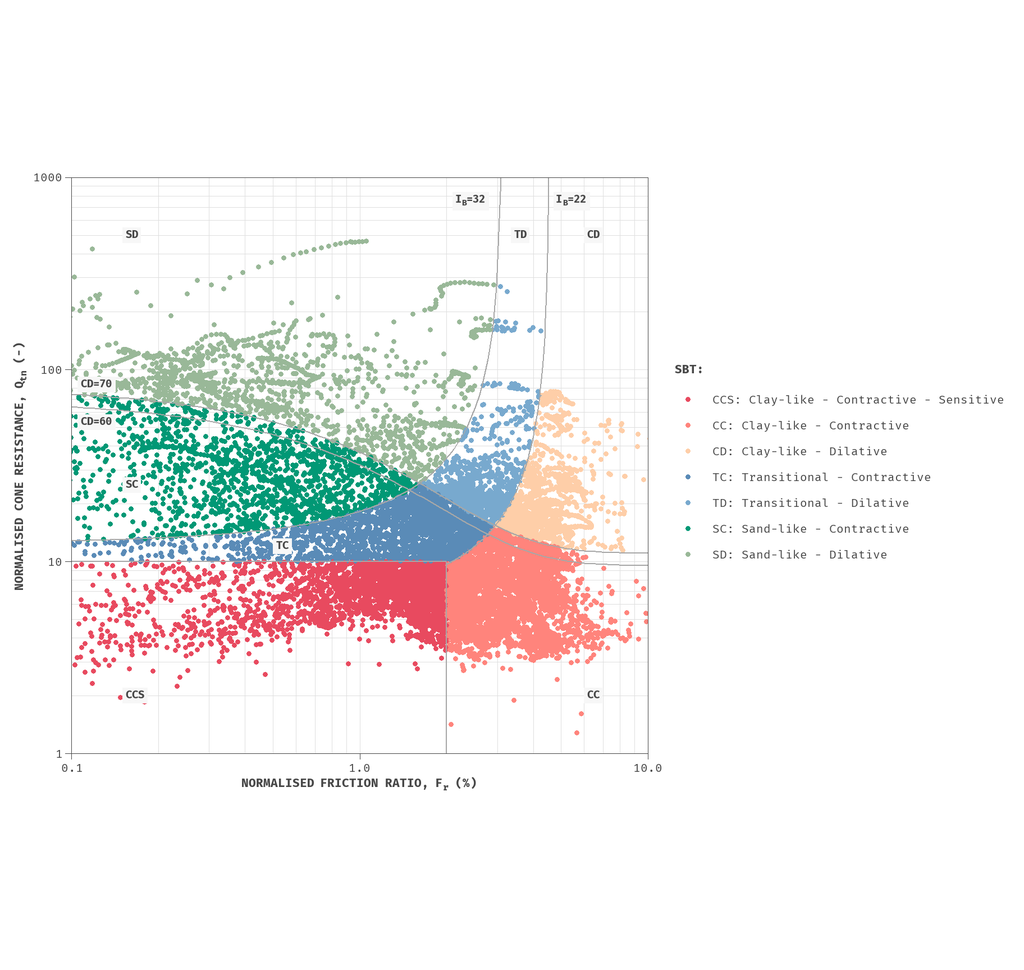

### SEPARATED

Separated plots for each `SBT` zone:

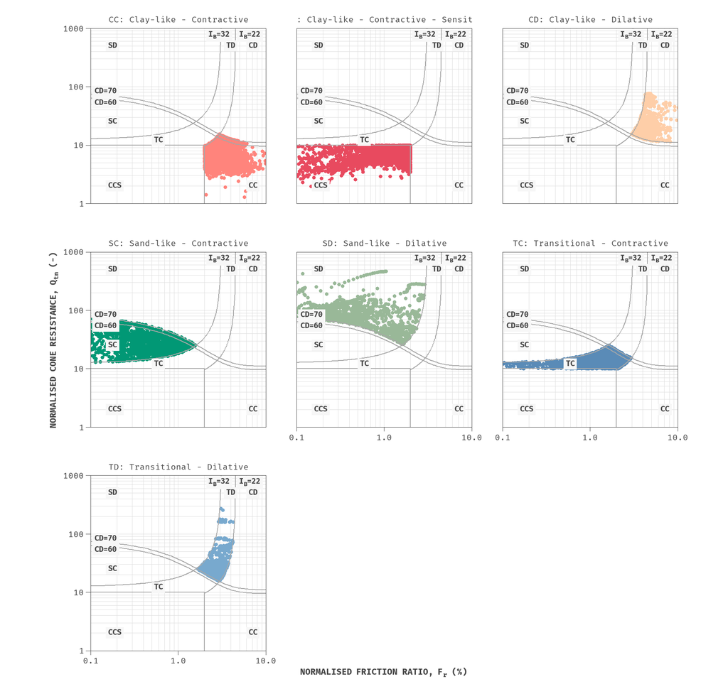

## 2.3 Schneider et al. 2008 (modified Robertson 2016)

### ALL ZONES

Same plot for all `SBT` zones:

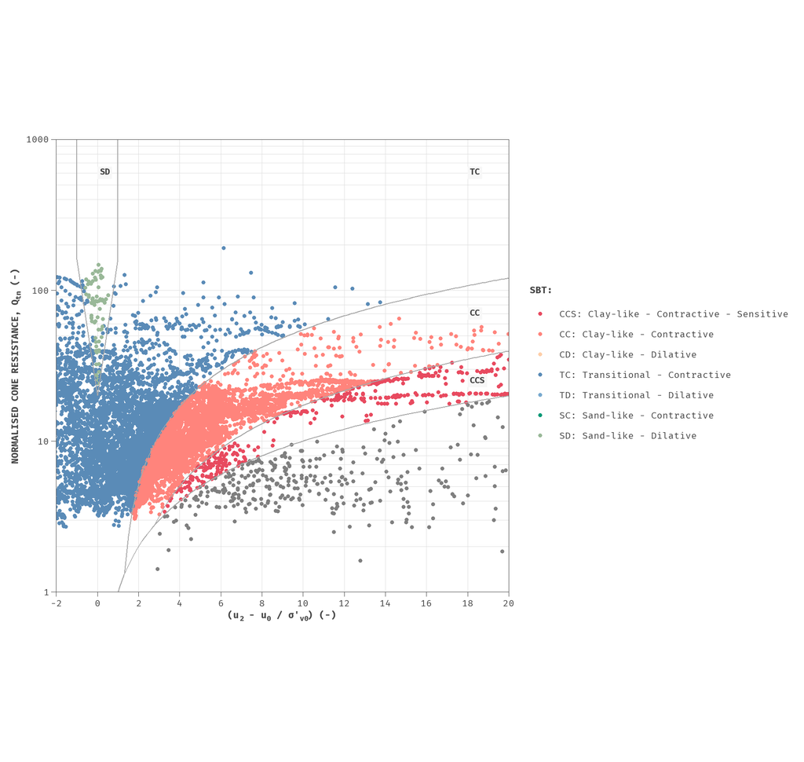

### SEPARATED

Separated plots for each `SBT` zone:

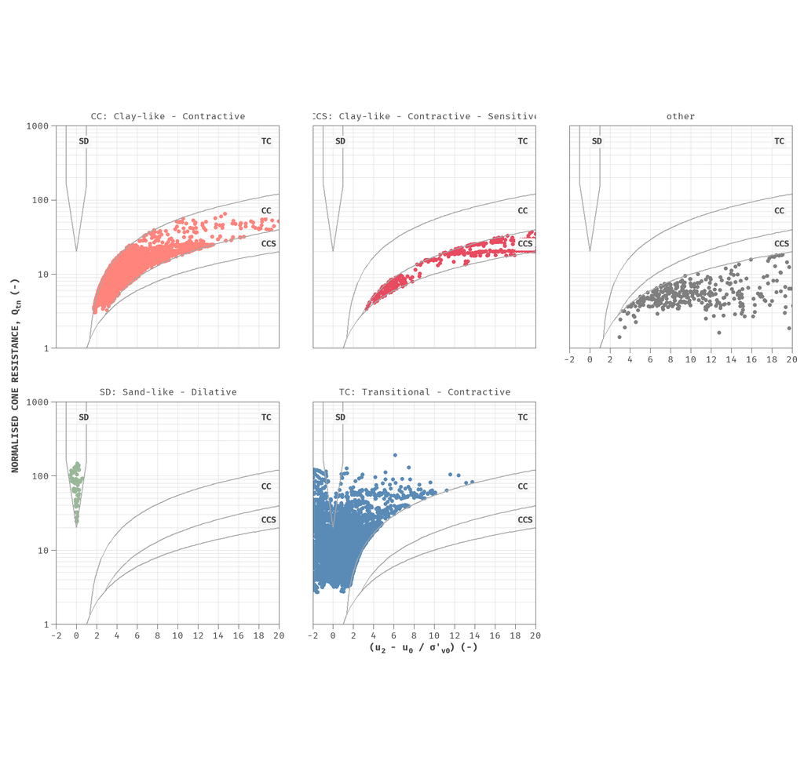

[^1]: Robertson, P.K. 2009. Interpretation of cone penetration tests - a unified approach. Canadian Geotechnical Journal, 46(11), pp.1337-1356.
[^2]: Robertson, P.K., 2016. Cone penetration test (CPT)-based soil behaviour type (SBT) classification system—an update. Canadian Geotechnical Journal, 53, pp.1910-19277.
[^3]: Schneider, J. A., Randolph, M. F., Mayne, P. W., & Ramsey, N. R., 2008. Analysis of factors influencing soil classification using normalized piezocone tip resistance and pore pressure parameters. Journal of Geotechnical and Geoenvironmental Engineering, ASCE. 134(11), pp. 1569-1586.